# Lesson 4: Model fit

Last updated in February 2021

## Goals for today

- Learn how to evaluate model fit using *R<sup>2</sup>* and ANOVA
- Learn how to compute them in R
- Learn about their limitations

## Model fit

- (Almost) any model can be fitted to our data, but not all models will fit equally well
- Three ways to evaluate model fit:
  - Checking assumptions the model makes using diagnostic plots (next lecture)
  - Fit indexes that summarize fit into a single number
  - Formal test of fit (ANOVA/F test)

## Coefficient of determination (R<sup>2</sup>)

- *The proportion of variance of the depended variable, which can be predicted using the independent variables*
  - e.g. if *R<sup>2</sup>* = 0.32, we can say our model predicts 32% of variance of the dependent variable (in our data)
  - Alternatively, the depend variable shares 32% of its variance with the independent variables
- Nothing about R<sup>2</sup> is causal!

## Coefficient of determination (R<sup>2</sup>)

- Formally, *R<sup>2</sup>* is defined as:

\[ R^{2} =1 - \frac{Sum \: of \: Squares_{residual} }{Sum \: of \: Squares_{total}} \]

Or perhaps in a more interpretable way:

\[ R^{2} =1 - \frac{Sum \: of \: Squares_{our\:model} }{Sum \: of \: Squares_{intercept\:only\:model}} \]

## Coefficient of determination (R<sup>2</sup>)

- Intercept only model is one with zero predictors, predictions are made solely based on the grand mean (mean of the dependent variable)
- This is the “worst” possible model

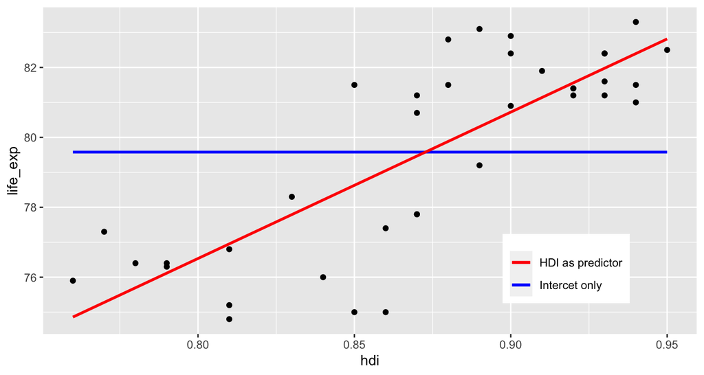

## Coefficient of determination

- *R<sup>2</sup>* tells us how much we reduced the prediction error by adding our predictors
- if *R<sup>2</sup>* = 0, then our model is as “good” as if we had no predictor at all
- if *R<sup>2</sup>* = 1, then we predict our data perfectly
- There is no universal cut-off for when *R<sup>2</sup>* is good or bad
  - In laboratory calibrations, *R<sup>2</sup>* < 0.99 is considered bad and a sign of an equipment failure
  - In day to day stock market, *R<sup>2</sup>* > 0.02 is considered good and such models are used for trading.

## ANOVA

- We can also compare two models formally, using ANOVA/F test
- Similar classic to ANOVA
- Null hypothesis: All regression coefficients (except for intercept) are 0.

## ANOVA

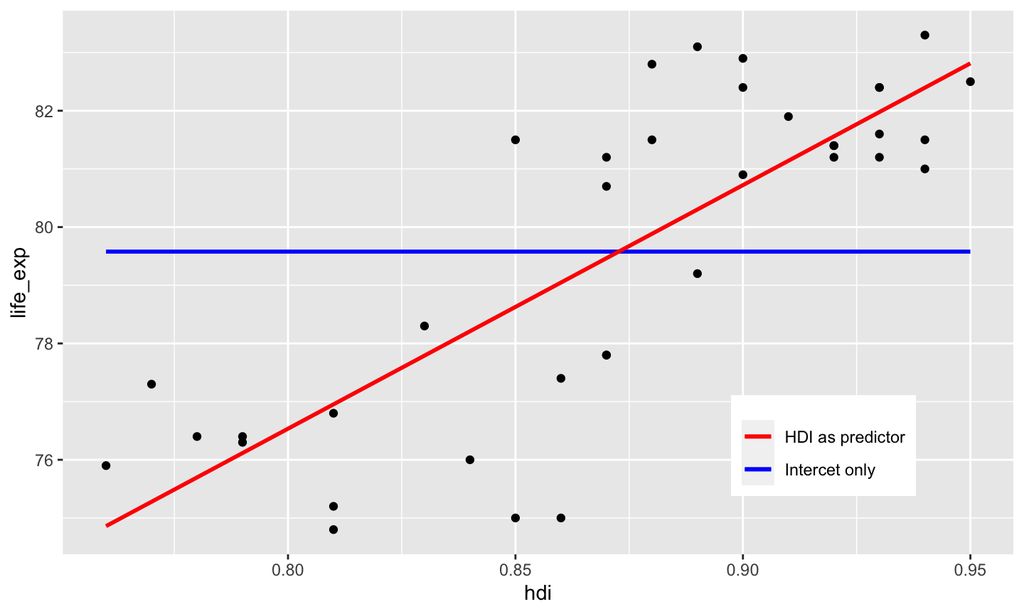

## ANOVA

- We can compare against the intercept only model, i.e. is our model better than model with no predictors?

```r
mod1 = lm(life_exp ~ hdi, data = countries)
anova(mod1)
```

```
## Analysis of Variance Table
##
## Response: life_exp
##           Df Sum Sq Mean Sq F value    Pr(>F)
## hdi        1 184.65 184.654  63.047 2.441e-09 ***
## Residuals 35 102.51   2.929
## ---
## Signif. codes:  0 '***' 0.001 '**' 0.01 '*' 0.05 '.' 0.1 ' ' 1
```

## ANOVA

- We can also compare two of our models, i.e. does one predict better than the other?

```r
mod1 = lm(life_exp ~ hdi, data = countries)
mod2 = lm(life_exp ~ hdi + postsoviet, data = countries)
anova(mod1, mod2)
```

```
## Analysis of Variance Table
##
## Model 1: life_exp ~ hdi
## Model 2: life_exp ~ hdi + postsoviet
##   Res.Df     RSS Df Sum of Sq      F    Pr(>F)
## 1     35 102.509
## 2     34  59.186  1    43.322 24.887 1.777e-05 ***
## ---
## Signif. codes:  0 '***' 0.001 '**' 0.01 '*' 0.05 '.' 0.1 ' ' 1
```

## R Intermezzo!

## Limitations of *R<sup>2</sup>* and ANOVA

## Limitations of ANOVA for model comparison

- Nested models only
- All the classic limitations of null hypothesis testing
  - It is extremely unlikely for two models to “explain” the exact same amount of variance -> null hypothesis is almost always false by definition
  - Differences do not matter, if they are practically unimportant -> rejecting null hypothesis is by itself not particularly interesting
  - Power matters, just like with any other test -> not rejecting null hypothesis does not necessarily mean the two models predict the same amount of variance. We may just not have enough precision to identify the difference

## Limitations of *R<sup>2</sup>*

- *R<sup>2</sup>* is fundamentally a measure of predictive strength
- It may behave not intuitively when used for other than predictive modeling (and may mislead even for predictive modeling)
- There are 4 “gotchas” you need to be careful about

## Gotcha 1 - Model with higher *R<sup>2</sup>* does not neccesarily provide a better estimate of regression coefficients

## *R<sup>2</sup>* and coefficient bias

- We want to analyze the relationship between intelligence (`IQ`) and work diligence (`diligence`). We also know if our respondents have a university degree (`degree`).
- `degree` is related to both `IQ` and `diligence` - only those who are top 20% most intelligent or the top 20% most diligent people will obtain a university degree
- Should we control for `degree` or not? For prediction? For explanation?
- (Truth : `intelligence = 0.1*diligence`, but let’s pretend we don’t know)

## *R<sup>2</sup>* and coefficient bias

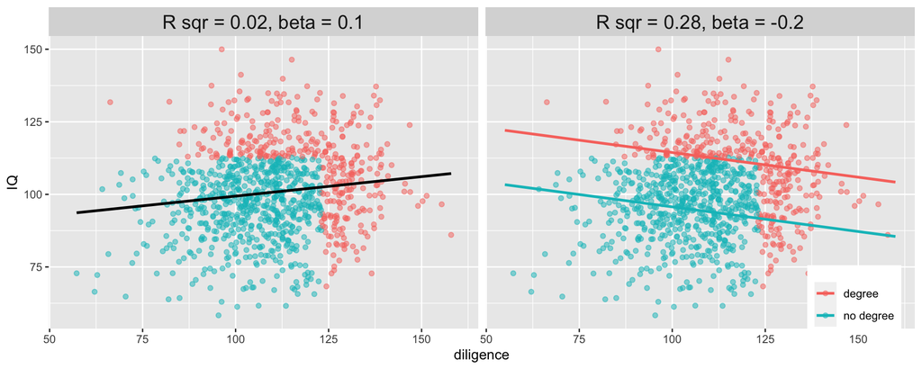

- Controlling for `degree` leads to higher *R<sup>2</sup>*, but incorrect coefficient estimate!
- Not controlling for `degree` actually provides better estimate of the relationship (remember, true value = 0.1)

## *R<sup>2</sup>* and coefficient bias

- Conclusion: If the goal of an analysis is the interpretation of regression coefficients, do not select variables based on *R<sup>2</sup>*.

## Gotcha 2 - *R<sup>2</sup>* depends on the variance of the dependent variable

## *R<sup>2</sup>* and the variance of dependent variable

- Consider variable \(x\) and 3 variables \(y_1\), \(y_2\), \(y_3\)
- The relationship between \(x\) and all \(y_i\) is the same:
  - \(y_i = 0 + 10*x\)
- Each of \(y_i\) has a different standard deviation:
  - \(sd_{y_1} = 50\), \(sd_{y_2} = 100\) and \(sd_{y_3} = 150\)

## *R<sup>2</sup>* and the variance of dependent variable

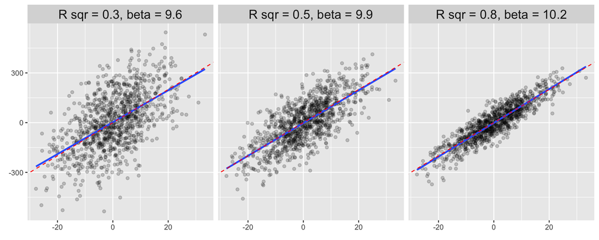

- Notice that *R<sup>2</sup>* varies widely, despite all models being perfectly specified and describing the relationship correctly.

## *R<sup>2</sup>* and the variance of dependent variable

- Even perfectly specified model (i.e. all relevant variables present, relationships set up correctly) can have low *R<sup>2</sup>* due to random error
- Low *R<sup>2</sup>* does not necessarily mean the estimates are incorrect (biased)
- Low *R<sup>2</sup>* can simply mean that we cannot explain a social phenomenon in its entirety, but that is almost never our goal.
- Conclusion: If our goal is substantive interpretation of coefficients, *R<sup>2</sup>* is not a good measure of model’s quality

## Gotcha 3 - *R<sup>2</sup>* depends on the number of predictors

## *R<sup>2</sup>* depends on the number of predictors

- Consider variable \(y\) and 15 variables \(x_i\) (\(x_1, \: x_2, \:... \: x_{15}\))
- All of these variables are independent of each other
- What happens to *R<sup>2</sup>*, if we start adding \(x_i\) variables as predictors?

## *R<sup>2</sup>* depends on the number of predictors

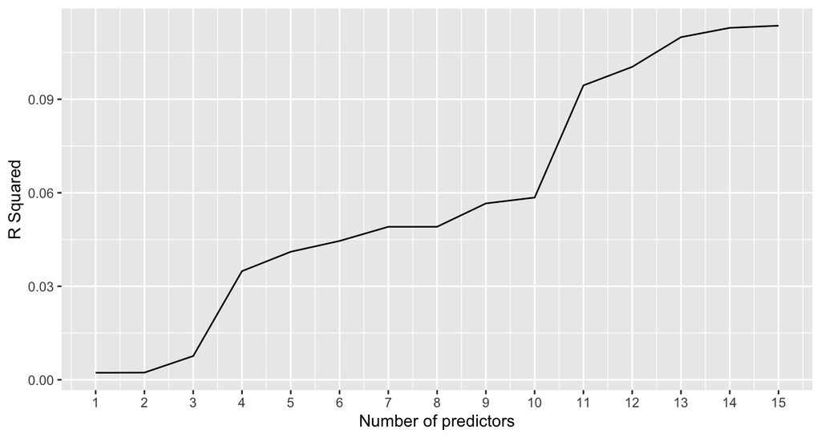

- Notice that the more predictors in the model, the higher the *R<sup>2</sup>*, even if the dependent variable \(y\) is not related to any of the independent variables \(x_i\)

## *R<sup>2</sup>* depends on the number of predictors

- *R<sup>2</sup>* will increase (almost) every time we add a new predictor, because even if there is no correlation between two variables in the population, sample correlation will rarely be exactly 0 (due to sampling error)
- Consequently, to some extent we are predicting random noise (this is the problem of overfitting in predictive models)

## *R<sup>2</sup>* depends on the number of predictors

- *Adjusted R<sup>2</sup>* (Henri, 1961) controls for the number of predictors in the model (represented by the degrees of freedom)

\[ R^{2}_{adj} = 1 - (1 - R^{2}) * \frac{no. \: of \: observations - 1}{no. \: of \: observations - no. \: of \: parameters - 1} \]

- *Adjusted R<sup>2</sup>* only increases when the contribution of a new predictor is bigger than what we would expect by chance
- Conclusion: Use *Adjusted R<sup>2</sup>* when you are comparing models with different number of predictors

## Gotcha 4 - *R<sup>2</sup>* depends on the range of independent variables

## *R<sup>2</sup>* depends on the range of independent variables

- Consider variables \(y\) and \(x\)
- \(x\) is normally distributed with mean of 50 and standard deviation of 15
- The relationship between them is \(y = 3*x\) with residual standard deviation of 50
- What would happen if we limited the range of \(x\) to <35;65> ?

## *R<sup>2</sup>* and the range of independent variable

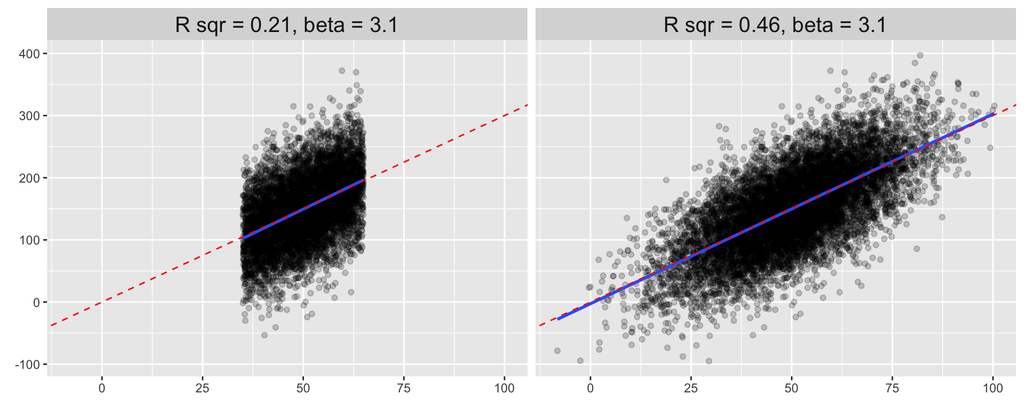

- Notice that despite the coefficients being (virtually) the same, *R<sup>2</sup>* gets lower as the range of data gets narrower

## *R<sup>2</sup>* and the range of independent variable

- *R<sup>2</sup>* will naturally get lower as we restrict the range of independent variables
- This does not mean the model is any less valid, just that predictive power is lower
  - e.g. model predicting attitudes based on income will have lower *R<sup>2</sup>* in populations with smaller income differences (all else held constant).
- Conclusion - Trimming data, either by filtering out subpopulations or removing outliers, will lower *R<sup>2</sup>*

## Limitations of *R<sup>2</sup>*

- To summarize:
- If the goal is hypothesis testing or causal inference, *R<sup>2</sup>* cannot be used to select which variables to include into the model. Doing so can be actively harmful
- If the goal is to test a hypothesis or describe a relationship, *R<sup>2</sup>* doesn’t indicate quality of the model
- *R<sup>2</sup>* has to be adjusted when comparing predictive power of models with different number of predictors
- The value of *R<sup>2</sup>* depends on the range of the independent variables

## References

Henri, etc T. (1961). *Economic forecasts and policy* (2nd edition). North-Holland Pub. Co.